# Inference Lab 1: the Bootstrap

Data Science Team

## Today’s Activity

Today’s activity on the bootstrap will start with a demo of how to code a bootstrap for one or two variables.

```r
library(dplyr)
library(ggplot2)
movies <- read.csv("https://web.stanford.edu/class/stats101/data/movies.csv", stringsAsFactors = FALSE)
glimpse(movies)
```

```
Rows: 2,961
Columns: 11
$ title               <chr> "Over the Hill to the Poorhouse", "The Broadway Melody", "42…
$ genre               <chr> "Crime", "Musical", "Comedy", "Comedy", "Comedy", "Animation…
$ director            <chr> "Harry F. Millarde", "Harry Beaumont", "Lloyd Bacon", "Mark …
$ year                <int> 1920, 1929, 1933, 1935, 1936, 1937, 1939, 1939, 1940, 1946, …
$ duration            <int> 110, 100, 89, 81, 87, 83, 102, 226, 88, 144, 172, 92, 102, 1…
$ gross               <int> 3000000, 2808000, 2300000, 3000000, 163245, 184925485, 22202…
$ budget              <int> 100000, 379000, 439000, 609000, 1500000, 2000000, 2800000, 3…
$ cast_facebook_likes <int> 4, 109, 995, 824, 352, 229, 2509, 1862, 1178, 2037, 1941, 10…
$ votes               <int> 5, 4546, 7921, 13269, 143086, 133348, 291875, 215340, 90360,…
$ reviews             <int> 2, 107, 162, 164, 331, 349, 746, 863, 252, 119, 332, 265, 95…
$ rating              <dbl> 4.8, 6.3, 7.7, 7.8, 8.6, 7.7, 8.1, 8.2, 7.5, 6.9, 8.1, 7.7, …
```

Below is the code for bootstrapping a generic statistic `stat` with data `x`, using B bootstrap samples:

# Bootstrapping a Univariate Statistic

```r
# x - data points for boot strap sample
# stat - function that represents statistic wanting to be calculated from the samples
# number of bootstrap samples

boot <- function(x, stat, B=1000){

  n <- length(x)
  boot_stats <- matrix(nrow=B)

  for(i in 1:B){
    indices <- sample(n, replace=TRUE)
    boot_stats[i] <- stat(x[indices])
  }

  return(boot_stats)
}
```

For example, if we want to bootstrap the mean with the data `x` and then compute the 2.5th percentile and the 97.5th percentile of the bootstrap replicates (we will see in class that this is a 95 percent bootstrap confidence interval):

```r
x = rnorm(100)
mean.x.boots <- boot(x, mean, 1000)

quantile(mean.x.boots, c(.025, 0.975))


hist(mean.x.boots)
```

**Task** Choose a genre and create a data frame that only contains that data for that genre (but not one with a trivial number of observations). Use this genre throughout.

```r
sort(table(movies$genre), decreasing = TRUE)
movies_comedy = subset(movies, genre == "Comedy")
```

**Task** Choose a variable and bootstrap the mean. Now calculate a 95% confidence interval using the quantile function on the bootstrap replicates. Also compute the 95% confidence interval using normal approximation: mean +/- 2 SE, where the SE is computed with the bootstrap.

```r
comedyVotes = movies_comedy$votes
mean.comedy.votes = boot(comedyVotes, mean, 1000)

quantile(mean.comedy.votes, c(0.025, 0.975))
```

```
    2.5%    97.5%
62202.07 74208.39
```

```r
SE = sd(mean.comedy.votes)
c(mean(movies_comedy$votes) - 2*SE, mean(movies_comedy$votes) + 2*SE)
```

```
[1] 61909.68 74627.35
```

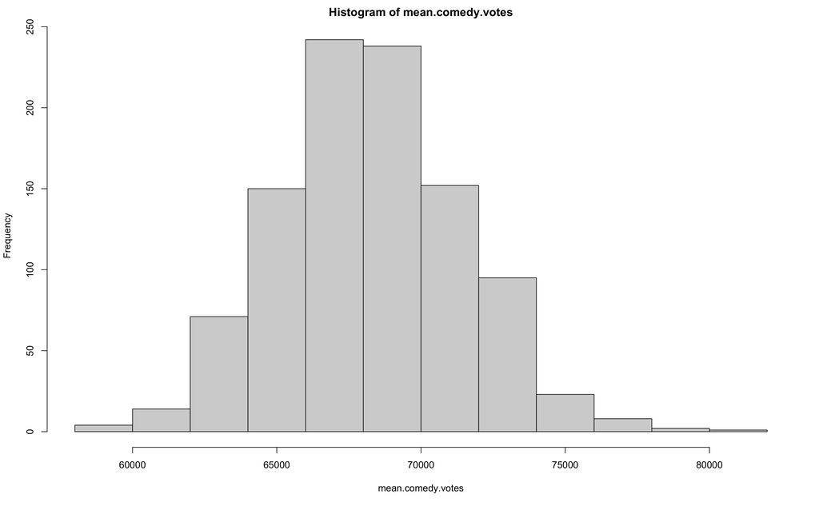

```r
hist(mean.comedy.votes)
```

**Question** Now bootstrap the median. Which do you expect to be more robust (stable across bootstrap simulations), the mean or the median, and why?

```r
median.comedy.votes = boot(comedyVotes, median, 1000)

quantile(median.comedy.votes, c(0.025, 0.975))
```

```
   2.5%   97.5%
34515.9 43543.5
```

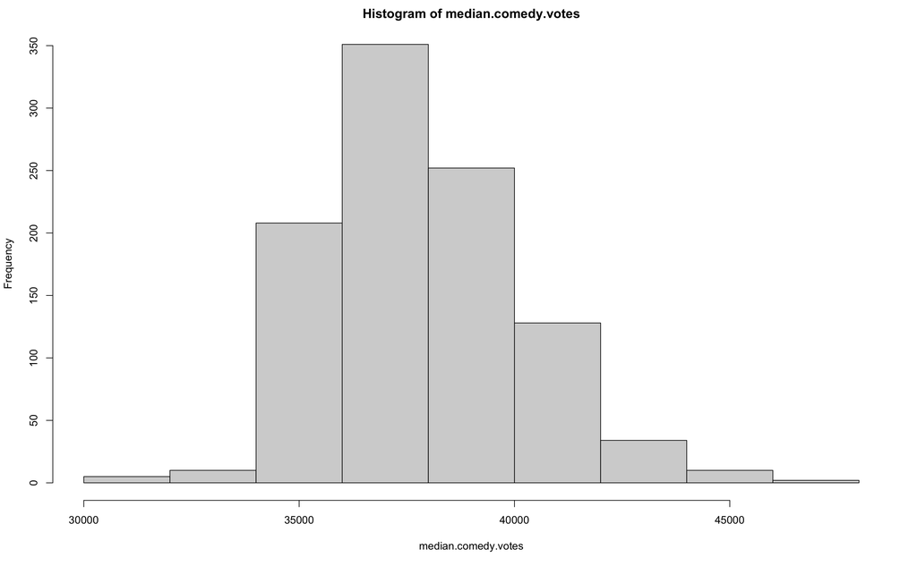

```r
hist(median.comedy.votes)
```

## Bootstrapping a Bivariate Statistic

The correlation coefficient that we discussed in class is also called Pearson’s correlation. There is a different correlation coefficient called Spearman’s correlation, which is more robust to outlying values (just as the median is more robust than the mean).

```r
bi_boot <- function(x, y, stat, B, ...){

  n <- length(x)
  boot_stats <- matrix(nrow=B)

  for(i in 1:B){
    indices <- sample(n, replace=TRUE)
    boot_stats[i] <- stat(x[indices], y[indices], ...)
  }

  return(boot_stats)

}

Nsims <- 10000
pearsons <- bi_boot(movies$gross, movies$budget, cor, Nsims)
spearmans <- bi_boot(movies$gross, movies$budget, cor, Nsims, method = "spearman")

# inspect quantiles
pearsons %>% quantile(c(0.025, .1, .5, .9, 0.975)) %>% round(4)
spearmans %>% quantile(c(0.025, .1, .5, .9, 0.975)) %>% round(4)

# or summary stats
mean(pearsons)
sd(pearsons)
mean(spearmans)
sd(spearmans)

# or use ggplot to display histogram
boot_cor <- data.frame(correlation = c(pearsons, spearmans),
                       type = c(rep("Pearson's", Nsims), rep("Spearman's", Nsims)))

ggplot(boot_cor, aes(x = correlation, fill=type)) + geom_histogram()
```

**Task** Choose two different continuous variables and bootstrap the Pearson’s correlation as well as the Spearman correlation. Plot the histograms along with the 95% confidence interval (from the quantiles). Also add a vertical line for the correlation in the full sample. Do you conclude the correlation is positive, negative, or that there is no clear evidence of correlation?

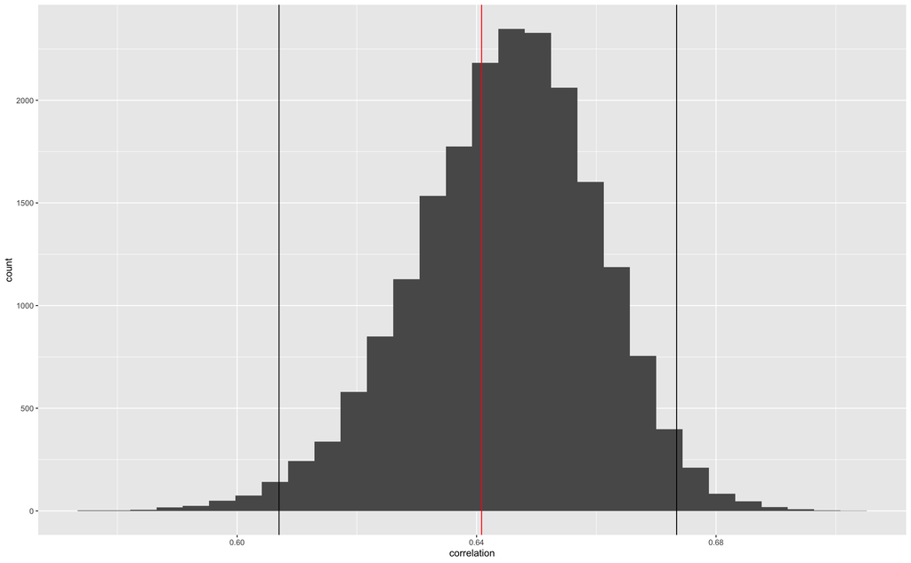

```r
bootplot = ggplot(subset(boot_cor, type = "Pearson's"), aes(x = correlation)) + geom_histogram()

bootplot = bootplot + geom_vline(xintercept = quantile(pearsons, c(0.025, 0.975)))
bootplot = bootplot + geom_vline(xintercept = cor(movies$gross, movies$budget), color = "red")
bootplot
```